# Probiotics_Trials-main

JM

12/2/2020

## Load libraries

```r
library(dada2)
library(ShortRead)
```

```r
library(ggplot2)
library(phyloseq)
library(vegan)
library(knitr)
library(ALDEx2)
library(CoDaSeq)
library(zCompositions)
library(igraph)
library(car)
library(grDevices)
library(propr)
library(cowplot)
library(randomcoloR)
library(dplyr)
library(reshape2)
library(tibble)
library(exactRankTests)
library(nlme)
library(data.table)
library(Rmisc)
writeLines(capture.output(sessionInfo()), "sessionInfo.txt")
```

## Quality-filter the sequencing reads and create Amplicon Sequence Variant (ASV) tables with DADA2

Put unjoined R1 and R2 fastq files, with adaptors and primers previously removed with cutadapt into a directory for DADA2. Here, our forward and reverse fastq filenames have format: SAMPLENAME_R1_cut.fastq.gz and SAMPLENAME_R2_cut.fastq.gz

*****If you have samples from multiple sequencing runs, you need to determine the sequence variants for each run separately, then merge the ASV tables. Here is the dada2 page on merging runs: https://benjjneb.github.io/dada2/bigdata_paired.html

Make sure the full path is updated at the beginning and ending of this code chunk

```r
#### 1st sequencing run
path <- "~/Desktop/Probiotics_Trials-main/cutadapt_NS1968R_Tank" ##update path as needed
list.files(path)
```

```
##  [1] "filtered"                            "McHD25-1_S50_L001_R1_cut.fastq.gz"
##  [3] "McHD25-1_S50_L001_R2_cut.fastq.gz"   "McHD25-21_S47_L001_R1_cut.fastq.gz"
##  [5] "McHD25-21_S47_L001_R2_cut.fastq.gz"  "McHD25-28_S46_L001_R1_cut.fastq.gz"
##  [7] "McHD25-28_S46_L001_R2_cut.fastq.gz"  "McHD25-3_S49_L001_R1_cut.fastq.gz"
##  [9] "McHD25-3_S49_L001_R2_cut.fastq.gz"   "McHD25-7_S48_L001_R1_cut.fastq.gz"
## [11] "McHD25-7_S48_L001_R2_cut.fastq.gz"   "McHD25-Pre_S51_L001_R1_cut.fastq.gz"
## [13] "McHD25-Pre_S51_L001_R2_cut.fastq.gz" "McHD26-1_S44_L001_R1_cut.fastq.gz"
## [15] "McHD26-1_S44_L001_R2_cut.fastq.gz"   "McHD26-21_S41_L001_R1_cut.fastq.gz"
## [17] "McHD26-21_S41_L001_R2_cut.fastq.gz"  "McHD26-28_S40_L001_R1_cut.fastq.gz"
## [19] "McHD26-28_S40_L001_R2_cut.fastq.gz"  "McHD26-3_S43_L001_R1_cut.fastq.gz"
## [21] "McHD26-3_S43_L001_R2_cut.fastq.gz"   "McHD26-7_S42_L001_R1_cut.fastq.gz"
## [23] "McHD26-7_S42_L001_R2_cut.fastq.gz"   "McHD26-Pre_S45_L001_R1_cut.fastq.gz"
## [25] "McHD26-Pre_S45_L001_R2_cut.fastq.gz" "McHD27-1_S37_L001_R1_cut.fastq.gz"
## [27] "McHD27-1_S37_L001_R2_cut.fastq.gz"   "McHD27-21_S34_L001_R1_cut.fastq.gz"
## [29] "McHD27-21_S34_L001_R2_cut.fastq.gz"  "McHD27-28_S33_L001_R1_cut.fastq.gz"
## [31] "McHD27-28_S33_L001_R2_cut.fastq.gz"  "McHD27-3_S36_L001_R1_cut.fastq.gz"
## [33] "McHD27-3_S36_L001_R2_cut.fastq.gz"   "McHD27-7_S35_L001_R1_cut.fastq.gz"
## [35] "McHD27-7_S35_L001_R2_cut.fastq.gz"   "McHD27-Pre_S38_L001_R1_cut.fastq.gz"
## [37] "McHD27-Pre_S38_L001_R2_cut.fastq.gz" "McHD28-1_S31_L001_R1_cut.fastq.gz"
## [39] "McHD28-1_S31_L001_R2_cut.fastq.gz"   "McHD28-21_S29_L001_R1_cut.fastq.gz"
## [41] "McHD28-21_S29_L001_R2_cut.fastq.gz"  "McHD28-28_S28_L001_R1_cut.fastq.gz"
## [43] "McHD28-28_S28_L001_R2_cut.fastq.gz"  "McHD28-3_S30_L001_R1_cut.fastq.gz"
## [45] "McHD28-3_S30_L001_R2_cut.fastq.gz"   "McHD28-7_S24_L001_R1_cut.fastq.gz"
## [47] "McHD28-7_S24_L001_R2_cut.fastq.gz"   "McHD28-Pre_S32_L001_R1_cut.fastq.gz"
## [49] "McHD28-Pre_S32_L001_R2_cut.fastq.gz" "seqtab.rds"
```

```r
fnFs <- sort(list.files(path, pattern="_R1_cut.fastq.gz", full.names = TRUE))
fnRs <- sort(list.files(path, pattern="_R2_cut.fastq.gz", full.names = TRUE))
sample.names <- sapply(strsplit(basename(fnFs), "_"), `[`, 1)

# Perform filtering and trimming
filt_path <- file.path(path, "filtered")
filtFs <- file.path(filt_path, paste0(sample.names, "_F_filt.fastq.gz"))
filtRs <- file.path(filt_path, paste0(sample.names, "_R_filt.fastq.gz"))
out <- filterAndTrim(fnFs, filtFs, fnRs, filtRs, truncLen=c(150,150),
                     maxN=0, maxEE=c(2,2), truncQ=2, rm.phix=TRUE,
                     compress=TRUE, multithread=TRUE) # On Windows set multithread=FALSE
head(out)
```

```
##                                     reads.in reads.out
## McHD25-1_S50_L001_R1_cut.fastq.gz         84        47
## McHD25-21_S47_L001_R1_cut.fastq.gz        70        41
## McHD25-28_S46_L001_R1_cut.fastq.gz       173       116
## McHD25-3_S49_L001_R1_cut.fastq.gz        124        56
## McHD25-7_S48_L001_R1_cut.fastq.gz         81        45
## McHD25-Pre_S51_L001_R1_cut.fastq.gz      119        74
```

```r
# Learn the Error Rates, it TAKES TIME!
errF <- learnErrors(filtFs, multithread=TRUE)
```

```
## 913650 total bases in 6091 reads from 24 samples will be used for learning the error rates.
```

```r
errR <- learnErrors(filtRs, multithread=TRUE)
```

```
## 913650 total bases in 6091 reads from 24 samples will be used for learning the error rates.
```

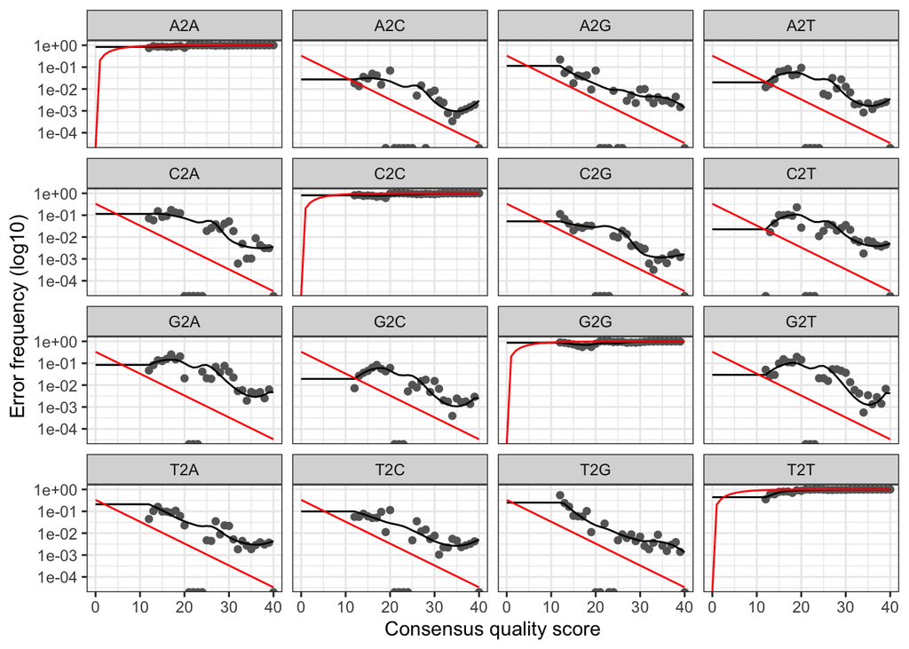

```r
plotErrors(errF, nominalQ=TRUE)
```

```r
# Dereplicate the filtered fastq files
derepFs <- derepFastq(filtFs, verbose=TRUE)
```

```
## Dereplicating sequence entries in Fastq file: ~/Desktop/Probiotics_Trials-main/cutadapt_NS1968R_Tank/filtered/McHD25-1_F_filt.fastq.gz
```

```
## Encountered 27 unique sequences from 47 total sequences read.
```

```
## Dereplicating sequence entries in Fastq file: ~/Desktop/Probiotics_Trials-main/cutadapt_NS1968R_Tank/filtered/McHD25-21_F_filt.fastq.gz
```

```
## Encountered 21 unique sequences from 41 total sequences read.
```

```
## Dereplicating sequence entries in Fastq file: ~/Desktop/Probiotics_Trials-main/cutadapt_NS1968R_Tank/filtered/McHD25-28_F_filt.fastq.gz
```

```
## Encountered 46 unique sequences from 116 total sequences read.
```

```
## Dereplicating sequence entries in Fastq file: ~/Desktop/Probiotics_Trials-main/cutadapt_NS1968R_Tank/filtered/McHD25-3_F_filt.fastq.gz
```

```
## Encountered 28 unique sequences from 56 total sequences read.
```

```
## Dereplicating sequence entries in Fastq file: ~/Desktop/Probiotics_Trials-main/cutadapt_NS1968R_Tank/filtered/McHD25-7_F_filt.fastq.gz
```

```
## Encountered 22 unique sequences from 45 total sequences read.
```

```
## Dereplicating sequence entries in Fastq file: ~/Desktop/Probiotics_Trials-main/cutadapt_NS1968R_Tank/filtered/McHD25-Pre_F_filt.fastq.gz
```

```
## Encountered 27 unique sequences from 74 total sequences read.
```

```
## Dereplicating sequence entries in Fastq file: ~/Desktop/Probiotics_Trials-main/cutadapt_NS1968R_Tank/filtered/McHD26-1_F_filt.fastq.gz
```

```
## Encountered 19 unique sequences from 83 total sequences read.
```

```
## Dereplicating sequence entries in Fastq file: ~/Desktop/Probiotics_Trials-main/cutadapt_NS1968R_Tank/filtered/McHD26-21_F_filt.fastq.gz
```

```
## Encountered 20 unique sequences from 84 total sequences read.
```

```
## Dereplicating sequence entries in Fastq file: ~/Desktop/Probiotics_Trials-main/cutadapt_NS1968R_Tank/filtered/McHD26-28_F_filt.fastq.gz
```

```
## Encountered 52 unique sequences from 352 total sequences read.
```

```
## Dereplicating sequence entries in Fastq file: ~/Desktop/Probiotics_Trials-main/cutadapt_NS1968R_Tank/filtered/McHD26-3_F_filt.fastq.gz
```

```
## Encountered 53 unique sequences from 316 total sequences read.
```

```
## Dereplicating sequence entries in Fastq file: ~/Desktop/Probiotics_Trials-main/cutadapt_NS1968R_Tank/filtered/McHD26-7_F_filt.fastq.gz
```

```
## Encountered 17 unique sequences from 95 total sequences read.
```

```
## Dereplicating sequence entries in Fastq file: ~/Desktop/Probiotics_Trials-main/cutadapt_NS1968R_Tank/filtered/McHD26-Pre_F_filt.fastq.gz
```

```
## Encountered 91 unique sequences from 260 total sequences read.
```

```
## Dereplicating sequence entries in Fastq file: ~/Desktop/Probiotics_Trials-main/cutadapt_NS1968R_Tank/filtered/McHD27-1_F_filt.fastq.gz
```

```
## Encountered 116 unique sequences from 719 total sequences read.
```

```
## Dereplicating sequence entries in Fastq file: ~/Desktop/Probiotics_Trials-main/cutadapt_NS1968R_Tank/filtered/McHD27-21_F_filt.fastq.gz
```

```
## Encountered 27 unique sequences from 96 total sequences read.
```

```
## Dereplicating sequence entries in Fastq file: ~/Desktop/Probiotics_Trials-main/cutadapt_NS1968R_Tank/filtered/McHD27-28_F_filt.fastq.gz
```

```
## Encountered 49 unique sequences from 227 total sequences read.
```

```
## Dereplicating sequence entries in Fastq file: ~/Desktop/Probiotics_Trials-main/cutadapt_NS1968R_Tank/filtered/McHD27-3_F_filt.fastq.gz
```

```
## Encountered 49 unique sequences from 308 total sequences read.
```

```
## Dereplicating sequence entries in Fastq file: ~/Desktop/Probiotics_Trials-main/cutadapt_NS1968R_Tank/filtered/McHD27-7_F_filt.fastq.gz
```

```
## Encountered 54 unique sequences from 218 total sequences read.
```

```
## Dereplicating sequence entries in Fastq file: ~/Desktop/Probiotics_Trials-main/cutadapt_NS1968R_Tank/filtered/McHD27-Pre_F_filt.fastq.gz
```

```
## Encountered 60 unique sequences from 416 total sequences read.
```

```
## Dereplicating sequence entries in Fastq file: ~/Desktop/Probiotics_Trials-main/cutadapt_NS1968R_Tank/filtered/McHD28-1_F_filt.fastq.gz
```

```
## Encountered 28 unique sequences from 91 total sequences read.
```

```
## Dereplicating sequence entries in Fastq file: ~/Desktop/Probiotics_Trials-main/cutadapt_NS1968R_Tank/filtered/McHD28-21_F_filt.fastq.gz
```

```
## Encountered 53 unique sequences from 213 total sequences read.
```

```
## Dereplicating sequence entries in Fastq file: ~/Desktop/Probiotics_Trials-main/cutadapt_NS1968R_Tank/filtered/McHD28-28_F_filt.fastq.gz
```

```
## Encountered 25 unique sequences from 121 total sequences read.
```

```
## Dereplicating sequence entries in Fastq file: ~/Desktop/Probiotics_Trials-main/cutadapt_NS1968R_Tank/filtered/McHD28-3_F_filt.fastq.gz
```

```
## Encountered 63 unique sequences from 373 total sequences read.
```

```
## Dereplicating sequence entries in Fastq file: ~/Desktop/Probiotics_Trials-main/cutadapt_NS1968R_Tank/filtered/McHD28-7_F_filt.fastq.gz
```

```
## Encountered 334 unique sequences from 1707 total sequences read.
```

```
## Dereplicating sequence entries in Fastq file: ~/Desktop/Probiotics_Trials-main/cutadapt_NS1968R_Tank/filtered/McHD28-Pre_F_filt.fastq.gz
```

```
## Encountered 6 unique sequences from 33 total sequences read.
```

```r
derepRs <- derepFastq(filtRs, verbose=TRUE)
```

```
## Dereplicating sequence entries in Fastq file: ~/Desktop/Probiotics_Trials-main/cutadapt_NS1968R_Tank/filtered/McHD25-1_R_filt.fastq.gz
```

```
## Encountered 28 unique sequences from 47 total sequences read.
```

```
## Dereplicating sequence entries in Fastq file: ~/Desktop/Probiotics_Trials-main/cutadapt_NS1968R_Tank/filtered/McHD25-21_R_filt.fastq.gz
```

```
## Encountered 18 unique sequences from 41 total sequences read.
```

```
## Dereplicating sequence entries in Fastq file: ~/Desktop/Probiotics_Trials-main/cutadapt_NS1968R_Tank/filtered/McHD25-28_R_filt.fastq.gz
```

```
## Encountered 47 unique sequences from 116 total sequences read.
```

```
## Dereplicating sequence entries in Fastq file: ~/Desktop/Probiotics_Trials-main/cutadapt_NS1968R_Tank/filtered/McHD25-3_R_filt.fastq.gz
```

```
## Encountered 30 unique sequences from 56 total sequences read.
```

```
## Dereplicating sequence entries in Fastq file: ~/Desktop/Probiotics_Trials-main/cutadapt_NS1968R_Tank/filtered/McHD25-7_R_filt.fastq.gz
```

```
## Encountered 23 unique sequences from 45 total sequences read.
```

```
## Dereplicating sequence entries in Fastq file: ~/Desktop/Probiotics_Trials-main/cutadapt_NS1968R_Tank/filtered/McHD25-Pre_R_filt.fastq.gz
```

```
## Encountered 26 unique sequences from 74 total sequences read.
```

```
## Dereplicating sequence entries in Fastq file: ~/Desktop/Probiotics_Trials-main/cutadapt_NS1968R_Tank/filtered/McHD26-1_R_filt.fastq.gz
```

```
## Encountered 22 unique sequences from 83 total sequences read.
```

```
## Dereplicating sequence entries in Fastq file: ~/Desktop/Probiotics_Trials-main/cutadapt_NS1968R_Tank/filtered/McHD26-21_R_filt.fastq.gz
```

```
## Encountered 21 unique sequences from 84 total sequences read.
```

```
## Dereplicating sequence entries in Fastq file: ~/Desktop/Probiotics_Trials-main/cutadapt_NS1968R_Tank/filtered/McHD26-28_R_filt.fastq.gz
```

```
## Encountered 73 unique sequences from 352 total sequences read.
```

```
## Dereplicating sequence entries in Fastq file: ~/Desktop/Probiotics_Trials-main/cutadapt_NS1968R_Tank/filtered/McHD26-3_R_filt.fastq.gz
```

```
## Encountered 58 unique sequences from 316 total sequences read.
```

```
## Dereplicating sequence entries in Fastq file: ~/Desktop/Probiotics_Trials-main/cutadapt_NS1968R_Tank/filtered/McHD26-7_R_filt.fastq.gz
```

```
## Encountered 21 unique sequences from 95 total sequences read.
```

```
## Dereplicating sequence entries in Fastq file: ~/Desktop/Probiotics_Trials-main/cutadapt_NS1968R_Tank/filtered/McHD26-Pre_R_filt.fastq.gz
```

```
## Encountered 90 unique sequences from 260 total sequences read.
```

```
## Dereplicating sequence entries in Fastq file: ~/Desktop/Probiotics_Trials-main/cutadapt_NS1968R_Tank/filtered/McHD27-1_R_filt.fastq.gz
```

```
## Encountered 142 unique sequences from 719 total sequences read.
```

```
## Dereplicating sequence entries in Fastq file: ~/Desktop/Probiotics_Trials-main/cutadapt_NS1968R_Tank/filtered/McHD27-21_R_filt.fastq.gz
```

```
## Encountered 24 unique sequences from 96 total sequences read.
```

```
## Dereplicating sequence entries in Fastq file: ~/Desktop/Probiotics_Trials-main/cutadapt_NS1968R_Tank/filtered/McHD27-28_R_filt.fastq.gz
```

```
## Encountered 48 unique sequences from 227 total sequences read.
```

```
## Dereplicating sequence entries in Fastq file: ~/Desktop/Probiotics_Trials-main/cutadapt_NS1968R_Tank/filtered/McHD27-3_R_filt.fastq.gz
```

```
## Encountered 43 unique sequences from 308 total sequences read.
```

```
## Dereplicating sequence entries in Fastq file: ~/Desktop/Probiotics_Trials-main/cutadapt_NS1968R_Tank/filtered/McHD27-7_R_filt.fastq.gz
```

```
## Encountered 55 unique sequences from 218 total sequences read.
```

```
## Dereplicating sequence entries in Fastq file: ~/Desktop/Probiotics_Trials-main/cutadapt_NS1968R_Tank/filtered/McHD27-Pre_R_filt.fastq.gz
```

```
## Encountered 78 unique sequences from 416 total sequences read.
```

```
## Dereplicating sequence entries in Fastq file: ~/Desktop/Probiotics_Trials-main/cutadapt_NS1968R_Tank/filtered/McHD28-1_R_filt.fastq.gz
```

```
## Encountered 27 unique sequences from 91 total sequences read.
```

```
## Dereplicating sequence entries in Fastq file: ~/Desktop/Probiotics_Trials-main/cutadapt_NS1968R_Tank/filtered/McHD28-21_R_filt.fastq.gz
```

```
## Encountered 48 unique sequences from 213 total sequences read.
```

```
## Dereplicating sequence entries in Fastq file: ~/Desktop/Probiotics_Trials-main/cutadapt_NS1968R_Tank/filtered/McHD28-28_R_filt.fastq.gz
```

```
## Encountered 29 unique sequences from 121 total sequences read.
```

```
## Dereplicating sequence entries in Fastq file: ~/Desktop/Probiotics_Trials-main/cutadapt_NS1968R_Tank/filtered/McHD28-3_R_filt.fastq.gz
```

```
## Encountered 65 unique sequences from 373 total sequences read.
```

```
## Dereplicating sequence entries in Fastq file: ~/Desktop/Probiotics_Trials-main/cutadapt_NS1968R_Tank/filtered/McHD28-7_R_filt.fastq.gz
```

```
## Encountered 329 unique sequences from 1707 total sequences read.
```

```
## Dereplicating sequence entries in Fastq file: ~/Desktop/Probiotics_Trials-main/cutadapt_NS1968R_Tank/filtered/McHD28-Pre_R_filt.fastq.gz
```

```
## Encountered 9 unique sequences from 33 total sequences read.
```

```r
names(derepFs) <- sample.names
names(derepRs) <- sample.names
# Infer the sequence variants in each sample
dadaFs <- dada(derepFs, err=errF, multithread=TRUE)
```

```
## Sample 1 - 47 reads in 27 unique sequences.
## Sample 2 - 41 reads in 21 unique sequences.
## Sample 3 - 116 reads in 46 unique sequences.
## Sample 4 - 56 reads in 28 unique sequences.
## Sample 5 - 45 reads in 22 unique sequences.
## Sample 6 - 74 reads in 27 unique sequences.
## Sample 7 - 83 reads in 19 unique sequences.
## Sample 8 - 84 reads in 20 unique sequences.
## Sample 9 - 352 reads in 52 unique sequences.
## Sample 10 - 316 reads in 53 unique sequences.
## Sample 11 - 95 reads in 17 unique sequences.
## Sample 12 - 260 reads in 91 unique sequences.
## Sample 13 - 719 reads in 116 unique sequences.
## Sample 14 - 96 reads in 27 unique sequences.
## Sample 15 - 227 reads in 49 unique sequences.
## Sample 16 - 308 reads in 49 unique sequences.
## Sample 17 - 218 reads in 54 unique sequences.
## Sample 18 - 416 reads in 60 unique sequences.
## Sample 19 - 91 reads in 28 unique sequences.
## Sample 20 - 213 reads in 53 unique sequences.
## Sample 21 - 121 reads in 25 unique sequences.
## Sample 22 - 373 reads in 63 unique sequences.
## Sample 23 - 1707 reads in 334 unique sequences.
## Sample 24 - 33 reads in 6 unique sequences.
```

```r
dadaRs <- dada(derepRs, err=errR, multithread=TRUE)
```

```
## Sample 1 - 47 reads in 28 unique sequences.
## Sample 2 - 41 reads in 18 unique sequences.
## Sample 3 - 116 reads in 47 unique sequences.
## Sample 4 - 56 reads in 30 unique sequences.
## Sample 5 - 45 reads in 23 unique sequences.
## Sample 6 - 74 reads in 26 unique sequences.
## Sample 7 - 83 reads in 22 unique sequences.
## Sample 8 - 84 reads in 21 unique sequences.
## Sample 9 - 352 reads in 73 unique sequences.
## Sample 10 - 316 reads in 58 unique sequences.
## Sample 11 - 95 reads in 21 unique sequences.
## Sample 12 - 260 reads in 90 unique sequences.
## Sample 13 - 719 reads in 142 unique sequences.
## Sample 14 - 96 reads in 24 unique sequences.
## Sample 15 - 227 reads in 48 unique sequences.
## Sample 16 - 308 reads in 43 unique sequences.
## Sample 17 - 218 reads in 55 unique sequences.
## Sample 18 - 416 reads in 78 unique sequences.
## Sample 19 - 91 reads in 27 unique sequences.
## Sample 20 - 213 reads in 48 unique sequences.
## Sample 21 - 121 reads in 29 unique sequences.
## Sample 22 - 373 reads in 65 unique sequences.
## Sample 23 - 1707 reads in 329 unique sequences.
## Sample 24 - 33 reads in 9 unique sequences.
```

```r
# Inspecting the dada-class object returned by dada:
dadaFs[[1]]
```

```
## dada-class: object describing DADA2 denoising results
## 9 sequence variants were inferred from 27 input unique sequences.
## Key parameters: OMEGA_A = 1e-40, OMEGA_C = 1e-40, BAND_SIZE = 16
```

```r
# Merge the denoised forward and reverse reads:
mergers <- mergePairs(dadaFs, derepFs, dadaRs, derepRs, verbose=TRUE)
```

```
## 27 paired-reads (in 7 unique pairings) successfully merged out of 27 (in 7 pairings) input.
```

```
## 29 paired-reads (in 4 unique pairings) successfully merged out of 31 (in 5 pairings) input.
```

```
## 82 paired-reads (in 8 unique pairings) successfully merged out of 92 (in 10 pairings) input.
```

```
## 33 paired-reads (in 6 unique pairings) successfully merged out of 34 (in 7 pairings) input.
```

```
## 32 paired-reads (in 6 unique pairings) successfully merged out of 32 (in 6 pairings) input.
```

```
## 72 paired-reads (in 10 unique pairings) successfully merged out of 72 (in 10 pairings) input.
```

```
## 73 paired-reads (in 3 unique pairings) successfully merged out of 76 (in 4 pairings) input.
```

```
## 71 paired-reads (in 6 unique pairings) successfully merged out of 77 (in 8 pairings) input.
```

```
## 332 paired-reads (in 7 unique pairings) successfully merged out of 336 (in 8 pairings) input.
```

```
## 315 paired-reads (in 20 unique pairings) successfully merged out of 315 (in 20 pairings) input.
```

```
## 94 paired-reads (in 5 unique pairings) successfully merged out of 94 (in 5 pairings) input.
```

```
## 207 paired-reads (in 18 unique pairings) successfully merged out of 217 (in 21 pairings) input.
```

```
## 680 paired-reads (in 27 unique pairings) successfully merged out of 702 (in 28 pairings) input.
```

```
## 86 paired-reads (in 8 unique pairings) successfully merged out of 92 (in 9 pairings) input.
```

```
## 218 paired-reads (in 8 unique pairings) successfully merged out of 221 (in 9 pairings) input.
```

```
## 302 paired-reads (in 11 unique pairings) successfully merged out of 302 (in 11 pairings) input.
```

```
## 194 paired-reads (in 16 unique pairings) successfully merged out of 202 (in 19 pairings) input.
```

```
## 407 paired-reads (in 15 unique pairings) successfully merged out of 408 (in 16 pairings) input.
```

```
## 85 paired-reads (in 12 unique pairings) successfully merged out of 85 (in 12 pairings) input.
```

```
## 205 paired-reads (in 11 unique pairings) successfully merged out of 206 (in 12 pairings) input.
```

```
## 114 paired-reads (in 7 unique pairings) successfully merged out of 114 (in 7 pairings) input.
```

```
## 342 paired-reads (in 14 unique pairings) successfully merged out of 363 (in 16 pairings) input.
```

```
## 1631 paired-reads (in 107 unique pairings) successfully merged out of 1677 (in 117 pairings) input.
```

```
## 31 paired-reads (in 3 unique pairings) successfully merged out of 31 (in 3 pairings) input.
```

```r
# Inspect the merger data.frame from the first sample
head(mergers[[1]])
```

```
##                                                                                                                                                                                                                                                         sequence
## 1  TACGTAGGGTGCAAGCGTTGTTCGGAATCACTGGGCGTAAAGGGCGTGTAGGCGGAACGA…
## 2  TACGTAGGGTGCAAGCGTTATCCGGAATTATTGGGCGTAAAGAGCTCGTAGGCGGTTTGT…
## 3 TACAGAGGGTGCGAGCGTTAATCGGAATTACTGGGCGTAAAGCGAGTGTAGGTGGCTCAT…
## 4  TACGGAGGATGCAAGCGTTATCCGGAATTATTGGGCGTAAAGCGTCCGCAGGTGGTGCAT…
## 5  TACGGAGGGTGCGAGCGTTAATCGGAATTACTGGGCGTAAAGCGCATGCAGGTGGTTTGT…
## 6  TACGGAGGGTGCGAGCGTTAATCGGAATTACTGGGCGTAAAGCGCACGCAGGCGGTTTGT…
##   abundance forward reverse nmatch nmismatch nindel prefer accept
## 1         5       1       1     47         0      0      1   TRUE
## 2         5       5       6     47         0      0      1   TRUE
## 3         4       2       3     46         0      0      1   TRUE
## 4         4       3       2     47         0      0      1   TRUE
## 5         4       4       4     47         0      0      1   TRUE
## 6         3       6       5     47         0      0      1   TRUE
```

```r
# Construct sequence table
seqtab <- makeSequenceTable(mergers)
dim(seqtab)
```

```
## [1]  24 267
```

```r
# Inspect distribution of sequence lengths
table(nchar(getSequences(seqtab)))
```

```
##
## 169 227 236 251 252 253 254
##   1   1   1   2  11 237  14
```

```r
getN <- function(x) sum(getUniques(x))
track <- cbind(out, sapply(dadaFs, getN), sapply(mergers, getN), rowSums(seqtab))
colnames(track) <- c("input", "filtered", "denoised", "merged", "tabled")
rownames(track) <- sample.names
head(track)
```

```
##            input filtered denoised merged tabled
## McHD25-1      84       47       33     27     27
## McHD25-21     70       41       31     29     29
## McHD25-28    173      116       93     82     82
## McHD25-3     124       56       43     33     33
## McHD25-7      81       45       32     32     32
## McHD25-Pre   119       74       72     72     72
```

```r
write.table(track, "dada_read_stats1.txt",sep="\t",col.names=NA)

saveRDS(seqtab, "~/Desktop/Probiotics_Trials-main/cutadapt_NS1968R_Tank/seqtab.rds") ##update path as needed
```

```r
#### 2nd sequencing run
path <- "~/Desktop/Probiotics_Trials-main/cutadapt_NS1995_Tank" ##update path as needed
list.files(path)
```

```
##  [1] "filtered"                            "McHD25-1_S23_L001_R1_cut.fastq.gz"
##  [3] "McHD25-1_S23_L001_R2_cut.fastq.gz"   "McHD25-21_S20_L001_R1_cut.fastq.gz"
##  [5] "McHD25-21_S20_L001_R2_cut.fastq.gz"  "McHD25-28_S19_L001_R1_cut.fastq.gz"
##  [7] "McHD25-28_S19_L001_R2_cut.fastq.gz"  "McHD25-3_S22_L001_R1_cut.fastq.gz"
##  [9] "McHD25-3_S22_L001_R2_cut.fastq.gz"   "McHD25-7_S21_L001_R1_cut.fastq.gz"
## [11] "McHD25-7_S21_L001_R2_cut.fastq.gz"   "McHD26-1_S17_L001_R1_cut.fastq.gz"
## [13] "McHD26-1_S17_L001_R2_cut.fastq.gz"   "McHD26-3_S16_L001_R1_cut.fastq.gz"
## [15] "McHD26-3_S16_L001_R2_cut.fastq.gz"   "McHD26-Pre_S18_L001_R1_cut.fastq.gz"
## [17] "McHD26-Pre_S18_L001_R2_cut.fastq.gz" "McHD27-1_S15_L001_R1_cut.fastq.gz"
## [19] "McHD27-1_S15_L001_R2_cut.fastq.gz"   "McHD27-21_S13_L001_R1_cut.fastq.gz"
## [21] "McHD27-21_S13_L001_R2_cut.fastq.gz"  "McHD27-28_S12_L001_R1_cut.fastq.gz"
## [23] "McHD27-28_S12_L001_R2_cut.fastq.gz"  "McHD27-7_S14_L001_R1_cut.fastq.gz"
## [25] "McHD27-7_S14_L001_R2_cut.fastq.gz"   "McHD28-1_S10_L001_R1_cut.fastq.gz"
## [27] "McHD28-1_S10_L001_R2_cut.fastq.gz"   "McHD28-21_S6_L001_R1_cut.fastq.gz"
## [29] "McHD28-21_S6_L001_R2_cut.fastq.gz"   "McHD28-28_S5_L001_R1_cut.fastq.gz"
## [31] "McHD28-28_S5_L001_R2_cut.fastq.gz"   "McHD28-3_S9_L001_R1_cut.fastq.gz"
## [33] "McHD28-3_S9_L001_R2_cut.fastq.gz"    "McHD28-7_S8_L001_R1_cut.fastq.gz"
## [35] "McHD28-7_S8_L001_R2_cut.fastq.gz"    "McHD28-Pre_S11_L001_R1_cut.fastq.gz"
## [37] "McHD28-Pre_S11_L001_R2_cut.fastq.gz" "seqtab.rds"
```

```r
fnFs <- sort(list.files(path, pattern="_R1_cut.fastq.gz", full.names = TRUE))
fnRs <- sort(list.files(path, pattern="_R2_cut.fastq.gz", full.names = TRUE))
sample.names <- sapply(strsplit(basename(fnFs), "_"), `[`, 1)

# Perform filtering and trimming
filt_path <- file.path(path, "filtered")
filtFs <- file.path(filt_path, paste0(sample.names, "_F_filt.fastq.gz"))
filtRs <- file.path(filt_path, paste0(sample.names, "_R_filt.fastq.gz"))
out <- filterAndTrim(fnFs, filtFs, fnRs, filtRs, truncLen=c(150,150),
                     maxN=0, maxEE=c(2,2), truncQ=2, rm.phix=TRUE,
                     compress=TRUE, multithread=TRUE) # On Windows set multithread=FALSE
head(out)
```

```
##                                    reads.in reads.out
## McHD25-1_S23_L001_R1_cut.fastq.gz      2818      2341
## McHD25-21_S20_L001_R1_cut.fastq.gz     1315      1067
## McHD25-28_S19_L001_R1_cut.fastq.gz    10016      9125
## McHD25-3_S22_L001_R1_cut.fastq.gz      2110      1776
## McHD25-7_S21_L001_R1_cut.fastq.gz      2408      2166
## McHD26-1_S17_L001_R1_cut.fastq.gz     28540     24564
```

```r
# Learn the Error Rates, it TAKES TIME!
errF <- learnErrors(filtFs, multithread=TRUE)
```

```
## 30976050 total bases in 206507 reads from 18 samples will be used for learning the error rates.
```

```r
errR <- learnErrors(filtRs, multithread=TRUE)
```

```
## 30976050 total bases in 206507 reads from 18 samples will be used for learning the error rates.
```

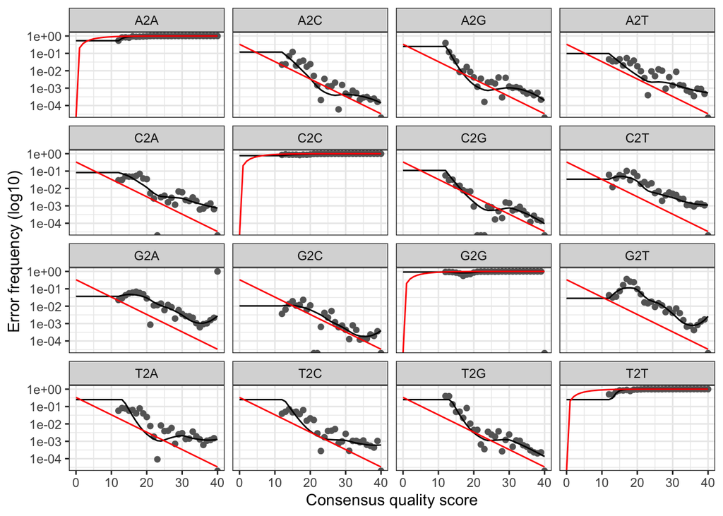

```r
plotErrors(errF, nominalQ=TRUE)
```

```r
# Dereplicate the filtered fastq files
derepFs <- derepFastq(filtFs, verbose=TRUE)
```

```
## Dereplicating sequence entries in Fastq file: ~/Desktop/Probiotics_Trials-main/cutadapt_NS1995_Tank/filtered/McHD25-1_F_filt.fastq.gz
```

```
## Encountered 591 unique sequences from 2341 total sequences read.
```

```
## Dereplicating sequence entries in Fastq file: ~/Desktop/Probiotics_Trials-main/cutadapt_NS1995_Tank/filtered/McHD25-21_F_filt.fastq.gz
```

```
## Encountered 281 unique sequences from 1067 total sequences read.
```

```
## Dereplicating sequence entries in Fastq file: ~/Desktop/Probiotics_Trials-main/cutadapt_NS1995_Tank/filtered/McHD25-28_F_filt.fastq.gz
```

```
## Encountered 1634 unique sequences from 9125 total sequences read.
```

```
## Dereplicating sequence entries in Fastq file: ~/Desktop/Probiotics_Trials-main/cutadapt_NS1995_Tank/filtered/McHD25-3_F_filt.fastq.gz
```

```
## Encountered 425 unique sequences from 1776 total sequences read.
```

```
## Dereplicating sequence entries in Fastq file: ~/Desktop/Probiotics_Trials-main/cutadapt_NS1995_Tank/filtered/McHD25-7_F_filt.fastq.gz
```

```
## Encountered 342 unique sequences from 2166 total sequences read.
```

```
## Dereplicating sequence entries in Fastq file: ~/Desktop/Probiotics_Trials-main/cutadapt_NS1995_Tank/filtered/McHD26-1_F_filt.fastq.gz
```

```
## Encountered 4880 unique sequences from 24564 total sequences read.
```

```
## Dereplicating sequence entries in Fastq file: ~/Desktop/Probiotics_Trials-main/cutadapt_NS1995_Tank/filtered/McHD26-3_F_filt.fastq.gz
```

```
## Encountered 1095 unique sequences from 5685 total sequences read.
```

```
## Dereplicating sequence entries in Fastq file: ~/Desktop/Probiotics_Trials-main/cutadapt_NS1995_Tank/filtered/McHD26-Pre_F_filt.fastq.gz
```

```
## Encountered 341 unique sequences from 1268 total sequences read.
```

```
## Dereplicating sequence entries in Fastq file: ~/Desktop/Probiotics_Trials-main/cutadapt_NS1995_Tank/filtered/McHD27-1_F_filt.fastq.gz
```

```
## Encountered 2099 unique sequences from 12595 total sequences read.
```

```
## Dereplicating sequence entries in Fastq file: ~/Desktop/Probiotics_Trials-main/cutadapt_NS1995_Tank/filtered/McHD27-21_F_filt.fastq.gz
```

```
## Encountered 1796 unique sequences from 7721 total sequences read.
```

```
## Dereplicating sequence entries in Fastq file: ~/Desktop/Probiotics_Trials-main/cutadapt_NS1995_Tank/filtered/McHD27-28_F_filt.fastq.gz
```

```
## Encountered 275 unique sequences from 1237 total sequences read.
```

```
## Dereplicating sequence entries in Fastq file: ~/Desktop/Probiotics_Trials-main/cutadapt_NS1995_Tank/filtered/McHD27-7_F_filt.fastq.gz
```

```
## Encountered 1288 unique sequences from 6365 total sequences read.
```

```
## Dereplicating sequence entries in Fastq file: ~/Desktop/Probiotics_Trials-main/cutadapt_NS1995_Tank/filtered/McHD28-1_F_filt.fastq.gz
```

```
## Encountered 85 unique sequences from 465 total sequences read.
```

```
## Dereplicating sequence entries in Fastq file: ~/Desktop/Probiotics_Trials-main/cutadapt_NS1995_Tank/filtered/McHD28-21_F_filt.fastq.gz
```

```
## Encountered 1926 unique sequences from 10111 total sequences read.
```

```
## Dereplicating sequence entries in Fastq file: ~/Desktop/Probiotics_Trials-main/cutadapt_NS1995_Tank/filtered/McHD28-28_F_filt.fastq.gz
```

```
## Encountered 1135 unique sequences from 7473 total sequences read.
```

```
## Dereplicating sequence entries in Fastq file: ~/Desktop/Probiotics_Trials-main/cutadapt_NS1995_Tank/filtered/McHD28-3_F_filt.fastq.gz
```

```
## Encountered 392 unique sequences from 1491 total sequences read.
```

```
## Dereplicating sequence entries in Fastq file: ~/Desktop/Probiotics_Trials-main/cutadapt_NS1995_Tank/filtered/McHD28-7_F_filt.fastq.gz
```

```
## Encountered 12775 unique sequences from 109748 total sequences read.
```

```
## Dereplicating sequence entries in Fastq file: ~/Desktop/Probiotics_Trials-main/cutadapt_NS1995_Tank/filtered/McHD28-Pre_F_filt.fastq.gz
```

```
## Encountered 301 unique sequences from 1309 total sequences read.
```

```r
derepRs <- derepFastq(filtRs, verbose=TRUE)
```

```
## Dereplicating sequence entries in Fastq file: ~/Desktop/Probiotics_Trials-main/cutadapt_NS1995_Tank/filtered/McHD25-1_R_filt.fastq.gz
```

```
## Encountered 689 unique sequences from 2341 total sequences read.
```

```
## Dereplicating sequence entries in Fastq file: ~/Desktop/Probiotics_Trials-main/cutadapt_NS1995_Tank/filtered/McHD25-21_R_filt.fastq.gz
```

```
## Encountered 281 unique sequences from 1067 total sequences read.
```

```
## Dereplicating sequence entries in Fastq file: ~/Desktop/Probiotics_Trials-main/cutadapt_NS1995_Tank/filtered/McHD25-28_R_filt.fastq.gz
```

```
## Encountered 2215 unique sequences from 9125 total sequences read.
```

```
## Dereplicating sequence entries in Fastq file: ~/Desktop/Probiotics_Trials-main/cutadapt_NS1995_Tank/filtered/McHD25-3_R_filt.fastq.gz
```

```
## Encountered 503 unique sequences from 1776 total sequences read.
```

```
## Dereplicating sequence entries in Fastq file: ~/Desktop/Probiotics_Trials-main/cutadapt_NS1995_Tank/filtered/McHD25-7_R_filt.fastq.gz
```

```
## Encountered 468 unique sequences from 2166 total sequences read.
```

```
## Dereplicating sequence entries in Fastq file: ~/Desktop/Probiotics_Trials-main/cutadapt_NS1995_Tank/filtered/McHD26-1_R_filt.fastq.gz
```

```
## Encountered 6366 unique sequences from 24564 total sequences read.
```

```
## Dereplicating sequence entries in Fastq file: ~/Desktop/Probiotics_Trials-main/cutadapt_NS1995_Tank/filtered/McHD26-3_R_filt.fastq.gz
```

```
## Encountered 1478 unique sequences from 5685 total sequences read.
```

```
## Dereplicating sequence entries in Fastq file: ~/Desktop/Probiotics_Trials-main/cutadapt_NS1995_Tank/filtered/McHD26-Pre_R_filt.fastq.gz
```

```
## Encountered 401 unique sequences from 1268 total sequences read.
```

```
## Dereplicating sequence entries in Fastq file: ~/Desktop/Probiotics_Trials-main/cutadapt_NS1995_Tank/filtered/McHD27-1_R_filt.fastq.gz
```

```
## Encountered 2777 unique sequences from 12595 total sequences read.
```

```
## Dereplicating sequence entries in Fastq file: ~/Desktop/Probiotics_Trials-main/cutadapt_NS1995_Tank/filtered/McHD27-21_R_filt.fastq.gz
```

```
## Encountered 1809 unique sequences from 7721 total sequences read.
```

```
## Dereplicating sequence entries in Fastq file: ~/Desktop/Probiotics_Trials-main/cutadapt_NS1995_Tank/filtered/McHD27-28_R_filt.fastq.gz
```

```
## Encountered 383 unique sequences from 1237 total sequences read.
```

```
## Dereplicating sequence entries in Fastq file: ~/Desktop/Probiotics_Trials-main/cutadapt_NS1995_Tank/filtered/McHD27-7_R_filt.fastq.gz
```

```
## Encountered 1708 unique sequences from 6365 total sequences read.
```

```
## Dereplicating sequence entries in Fastq file: ~/Desktop/Probiotics_Trials-main/cutadapt_NS1995_Tank/filtered/McHD28-1_R_filt.fastq.gz
```

```
## Encountered 119 unique sequences from 465 total sequences read.
```

```
## Dereplicating sequence entries in Fastq file: ~/Desktop/Probiotics_Trials-main/cutadapt_NS1995_Tank/filtered/McHD28-21_R_filt.fastq.gz
```

```
## Encountered 2765 unique sequences from 10111 total sequences read.
```

```
## Dereplicating sequence entries in Fastq file: ~/Desktop/Probiotics_Trials-main/cutadapt_NS1995_Tank/filtered/McHD28-28_R_filt.fastq.gz
```

```
## Encountered 1705 unique sequences from 7473 total sequences read.
```

```
## Dereplicating sequence entries in Fastq file: ~/Desktop/Probiotics_Trials-main/cutadapt_NS1995_Tank/filtered/McHD28-3_R_filt.fastq.gz
```

```
## Encountered 473 unique sequences from 1491 total sequences read.
```

```
## Dereplicating sequence entries in Fastq file: ~/Desktop/Probiotics_Trials-main/cutadapt_NS1995_Tank/filtered/McHD28-7_R_filt.fastq.gz
```

```
## Encountered 11814 unique sequences from 109748 total sequences read.
```

```
## Dereplicating sequence entries in Fastq file: ~/Desktop/Probiotics_Trials-main/cutadapt_NS1995_Tank/filtered/McHD28-Pre_R_filt.fastq.gz
```

```
## Encountered 370 unique sequences from 1309 total sequences read.
```

```r
names(derepFs) <- sample.names
names(derepRs) <- sample.names
# Infer the sequence variants in each sample
dadaFs <- dada(derepFs, err=errF, multithread=TRUE)
```

```
## Sample 1 - 2341 reads in 591 unique sequences.
## Sample 2 - 1067 reads in 281 unique sequences.
## Sample 3 - 9125 reads in 1634 unique sequences.
## Sample 4 - 1776 reads in 425 unique sequences.
## Sample 5 - 2166 reads in 342 unique sequences.
## Sample 6 - 24564 reads in 4880 unique sequences.
## Sample 7 - 5685 reads in 1095 unique sequences.
## Sample 8 - 1268 reads in 341 unique sequences.
## Sample 9 - 12595 reads in 2099 unique sequences.
## Sample 10 - 7721 reads in 1796 unique sequences.
## Sample 11 - 1237 reads in 275 unique sequences.
## Sample 12 - 6365 reads in 1288 unique sequences.
## Sample 13 - 465 reads in 85 unique sequences.
## Sample 14 - 10111 reads in 1926 unique sequences.
## Sample 15 - 7473 reads in 1135 unique sequences.
## Sample 16 - 1491 reads in 392 unique sequences.
## Sample 17 - 109748 reads in 12775 unique sequences.
## Sample 18 - 1309 reads in 301 unique sequences.
```

```r
dadaRs <- dada(derepRs, err=errR, multithread=TRUE)
```

```
## Sample 1 - 2341 reads in 689 unique sequences.
## Sample 2 - 1067 reads in 281 unique sequences.
## Sample 3 - 9125 reads in 2215 unique sequences.
## Sample 4 - 1776 reads in 503 unique sequences.
## Sample 5 - 2166 reads in 468 unique sequences.
## Sample 6 - 24564 reads in 6366 unique sequences.
## Sample 7 - 5685 reads in 1478 unique sequences.
## Sample 8 - 1268 reads in 401 unique sequences.
## Sample 9 - 12595 reads in 2777 unique sequences.
## Sample 10 - 7721 reads in 1809 unique sequences.
## Sample 11 - 1237 reads in 383 unique sequences.
## Sample 12 - 6365 reads in 1708 unique sequences.
## Sample 13 - 465 reads in 119 unique sequences.
## Sample 14 - 10111 reads in 2765 unique sequences.
## Sample 15 - 7473 reads in 1705 unique sequences.
## Sample 16 - 1491 reads in 473 unique sequences.
## Sample 17 - 109748 reads in 11814 unique sequences.
## Sample 18 - 1309 reads in 370 unique sequences.
```

```r
# Inspecting the dada-class object returned by dada:
dadaFs[[1]]
```

```
## dada-class: object describing DADA2 denoising results
## 48 sequence variants were inferred from 591 input unique sequences.
## Key parameters: OMEGA_A = 1e-40, OMEGA_C = 1e-40, BAND_SIZE = 16
```

```r
# Merge the denoised forward and reverse reads:
mergers <- mergePairs(dadaFs, derepFs, dadaRs, derepRs, verbose=TRUE)
```

```
## 2174 paired-reads (in 48 unique pairings) successfully merged out of 2210 (in 57 pairings) input.
```

```
## 1003 paired-reads (in 22 unique pairings) successfully merged out of 1012 (in 25 pairings) input.
```

```
## 8928 paired-reads (in 45 unique pairings) successfully merged out of 8993 (in 82 pairings) input.
```

```
## 1710 paired-reads (in 23 unique pairings) successfully merged out of 1731 (in 33 pairings) input.
```

```
## 2070 paired-reads (in 8 unique pairings) successfully merged out of 2108 (in 12 pairings) input.
```

```
## 23787 paired-reads (in 213 unique pairings) successfully merged out of 24292 (in 361 pairings) input.
```

```
## 5594 paired-reads (in 38 unique pairings) successfully merged out of 5616 (in 55 pairings) input.
```

```
## 1160 paired-reads (in 30 unique pairings) successfully merged out of 1165 (in 35 pairings) input.
```

```
## 12406 paired-reads (in 50 unique pairings) successfully merged out of 12454 (in 74 pairings) input.
```

```
## 7187 paired-reads (in 36 unique pairings) successfully merged out of 7347 (in 53 pairings) input.
```

```
## 1153 paired-reads (in 14 unique pairings) successfully merged out of 1188 (in 17 pairings) input.
```

```
## 6205 paired-reads (in 47 unique pairings) successfully merged out of 6216 (in 57 pairings) input.
```

```
## 449 paired-reads (in 15 unique pairings) successfully merged out of 449 (in 15 pairings) input.
```

```
## 9784 paired-reads (in 56 unique pairings) successfully merged out of 9839 (in 92 pairings) input.
```

```
## 7308 paired-reads (in 37 unique pairings) successfully merged out of 7405 (in 55 pairings) input.
```

```
## 1363 paired-reads (in 43 unique pairings) successfully merged out of 1388 (in 52 pairings) input.
```

```
## 109119 paired-reads (in 82 unique pairings) successfully merged out of 109456 (in 181 pairings) input.
```

```
## 1283 paired-reads (in 13 unique pairings) successfully merged out of 1284 (in 14 pairings) input.
```

```r
# Inspect the merger data.frame from the first sample
head(mergers[[1]])
```

```
##                                                                                                                                                                                                                                                         sequence
## 1 TACAGAGGGTGCGAGCGTTAATCGGAATTACTGGGCGTAAAGCGAGTGTAGGTGGCTCAT…
## 2  TACGGAGGGTGCAAGCGTTATCCGGATTTATTGGGTTTAAAGGGTCCGTAGGCGGATCTG…
## 3   TACGTATGGAGCGAGCGTTGTCCGGAATTATTGGGCGTAAAGGGTACGCAGGCGGTTTAA…
## 4  TACAGAGGATGCAAGCGTTATCCGGAATGATTGGGCGTAAAGCGTCTGTAGGTGGCTTTT…
## 5  TACGTAGGGTGCAAGCGTTATCCGGAATTATTGGGCGTAAAGAGCTCGTAGGCGGTTTGT…
## 6  TACGTAGGTGGCAAGCGTTGTCCGGATTTATTGGGCGTAAAGCGAGCGCAGGCGGTTCCT…
##   abundance forward reverse nmatch nmismatch nindel prefer accept
## 1       351       1       1     46         0      0      1   TRUE
## 2       214       2       2     47         0      0      2   TRUE
## 3       153       3       3     48         0      0      2   TRUE
## 4       100       5       4     47         0      0      2   TRUE
## 5       100       6       8     47         0      0      1   TRUE
## 6        75      18       5     47         0      0      2   TRUE
```

```r
# Construct sequence table
seqtab <- makeSequenceTable(mergers)
dim(seqtab)
```

```
## [1]  18 669
```

```r
# Inspect distribution of sequence lengths
table(nchar(getSequences(seqtab)))
```

```
##
## 169 170 221 227 251 252 253 254 255 256 272
##   1   1   1   4   2  35 593  27   3   1   1
```

```r
getN <- function(x) sum(getUniques(x))
track <- cbind(out, sapply(dadaFs, getN), sapply(mergers, getN), rowSums(seqtab))
colnames(track) <- c("input", "filtered", "denoised", "merged", "tabled")
rownames(track) <- sample.names
head(track)
```

```
##           input filtered denoised merged tabled
## McHD25-1   2818     2341     2228   2174   2174
## McHD25-21  1315     1067     1040   1003   1003
## McHD25-28 10016     9125     9027   8928   8928
## McHD25-3   2110     1776     1737   1710   1710
## McHD25-7   2408     2166     2108   2070   2070
## McHD26-1  28540    24564    24408  23787  23787
```

```r
write.table(track, "dada_read_stats2.txt",sep="\t",col.names=NA)

saveRDS(seqtab, "~/Desktop/Probiotics_Trials-main/cutadapt_NS1995_Tank/seqtab.rds") ##update path as needed
```

```r
#### 3rd sequencing run
path <- "~/Desktop/Probiotics_Trials-main/cutadapt_NS2051_Tank" ##update path as needed
list.files(path)
```

```
##  [1] "filtered"                            "McHD25-Pre_S93_L001_R1_cut.fastq.gz"
##  [3] "McHD25-Pre_S93_L001_R2_cut.fastq.gz" "McHD26-21_S95_L001_R1_cut.fastq.gz"
##  [5] "McHD26-21_S95_L001_R2_cut.fastq.gz"  "McHD26-28_S96_L001_R1_cut.fastq.gz"
##  [7] "McHD26-28_S96_L001_R2_cut.fastq.gz"  "McHD26-7_S94_L001_R1_cut.fastq.gz"
##  [9] "McHD26-7_S94_L001_R2_cut.fastq.gz"   "McHD27-3_S98_L001_R1_cut.fastq.gz"
## [11] "McHD27-3_S98_L001_R2_cut.fastq.gz"   "McHD27-Pre_S97_L001_R1_cut.fastq.gz"
## [13] "McHD27-Pre_S97_L001_R2_cut.fastq.gz" "seqtab.rds"
```

```r
fnFs <- sort(list.files(path, pattern="_R1_cut.fastq.gz", full.names = TRUE))
fnRs <- sort(list.files(path, pattern="_R2_cut.fastq.gz", full.names = TRUE))
sample.names <- sapply(strsplit(basename(fnFs), "_"), `[`, 1)

# Perform filtering and trimming
filt_path <- file.path(path, "filtered")
filtFs <- file.path(filt_path, paste0(sample.names, "_F_filt.fastq.gz"))
filtRs <- file.path(filt_path, paste0(sample.names, "_R_filt.fastq.gz"))
out <- filterAndTrim(fnFs, filtFs, fnRs, filtRs, truncLen=c(150,150),
                     maxN=0, maxEE=c(2,2), truncQ=2, rm.phix=TRUE,
                     compress=TRUE, multithread=TRUE) # On Windows set multithread=FALSE
head(out)
```

```
##                                     reads.in reads.out
## McHD25-Pre_S93_L001_R1_cut.fastq.gz     4137      1768
## McHD26-21_S95_L001_R1_cut.fastq.gz      2361       814
## McHD26-28_S96_L001_R1_cut.fastq.gz      2106       864
## McHD26-7_S94_L001_R1_cut.fastq.gz        605       231
## McHD27-3_S98_L001_R1_cut.fastq.gz      16769      7225
## McHD27-Pre_S97_L001_R1_cut.fastq.gz     3385      1410
```

```r
# Learn the Error Rates, it TAKES TIME!
errF <- learnErrors(filtFs, multithread=TRUE)
```

```
## 1846800 total bases in 12312 reads from 6 samples will be used for learning the error rates.
```

```r
errR <- learnErrors(filtRs, multithread=TRUE)
```

```
## 1846800 total bases in 12312 reads from 6 samples will be used for learning the error rates.
```

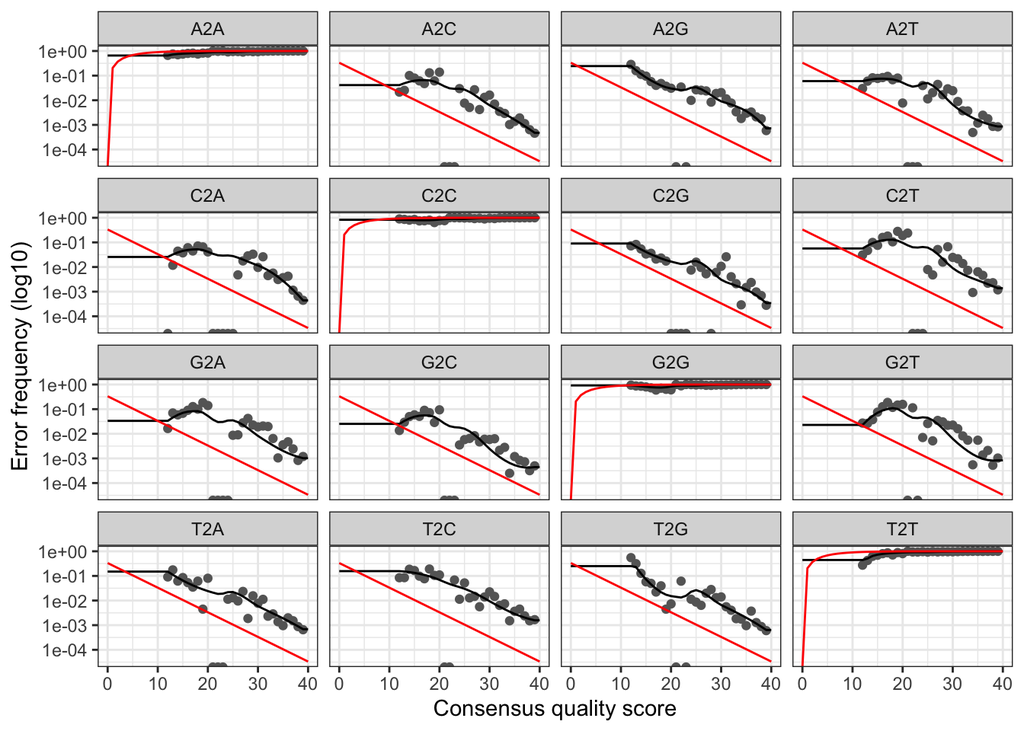

```r
plotErrors(errF, nominalQ=TRUE)
```

```r
# Dereplicate the filtered fastq files
derepFs <- derepFastq(filtFs, verbose=TRUE)
```

```
## Dereplicating sequence entries in Fastq file: ~/Desktop/Probiotics_Trials-main/cutadapt_NS2051_Tank/filtered/McHD25-Pre_F_filt.fastq.gz
```

```
## Encountered 344 unique sequences from 1768 total sequences read.
```

```
## Dereplicating sequence entries in Fastq file: ~/Desktop/Probiotics_Trials-main/cutadapt_NS2051_Tank/filtered/McHD26-21_F_filt.fastq.gz
```

```
## Encountered 266 unique sequences from 814 total sequences read.
```

```
## Dereplicating sequence entries in Fastq file: ~/Desktop/Probiotics_Trials-main/cutadapt_NS2051_Tank/filtered/McHD26-28_F_filt.fastq.gz
```

```
## Encountered 226 unique sequences from 864 total sequences read.
```

```
## Dereplicating sequence entries in Fastq file: ~/Desktop/Probiotics_Trials-main/cutadapt_NS2051_Tank/filtered/McHD26-7_F_filt.fastq.gz
```

```
## Encountered 95 unique sequences from 231 total sequences read.
```

```
## Dereplicating sequence entries in Fastq file: ~/Desktop/Probiotics_Trials-main/cutadapt_NS2051_Tank/filtered/McHD27-3_F_filt.fastq.gz
```

```
## Encountered 1061 unique sequences from 7225 total sequences read.
```

```
## Dereplicating sequence entries in Fastq file: ~/Desktop/Probiotics_Trials-main/cutadapt_NS2051_Tank/filtered/McHD27-Pre_F_filt.fastq.gz
```

```
## Encountered 385 unique sequences from 1410 total sequences read.
```

```r
derepRs <- derepFastq(filtRs, verbose=TRUE)
```

```
## Dereplicating sequence entries in Fastq file: ~/Desktop/Probiotics_Trials-main/cutadapt_NS2051_Tank/filtered/McHD25-Pre_R_filt.fastq.gz
```

```
## Encountered 334 unique sequences from 1768 total sequences read.
```

```
## Dereplicating sequence entries in Fastq file: ~/Desktop/Probiotics_Trials-main/cutadapt_NS2051_Tank/filtered/McHD26-21_R_filt.fastq.gz
```

```
## Encountered 264 unique sequences from 814 total sequences read.
```

```
## Dereplicating sequence entries in Fastq file: ~/Desktop/Probiotics_Trials-main/cutadapt_NS2051_Tank/filtered/McHD26-28_R_filt.fastq.gz
```

```
## Encountered 268 unique sequences from 864 total sequences read.
```

```
## Dereplicating sequence entries in Fastq file: ~/Desktop/Probiotics_Trials-main/cutadapt_NS2051_Tank/filtered/McHD26-7_R_filt.fastq.gz
```

```
## Encountered 94 unique sequences from 231 total sequences read.
```

```
## Dereplicating sequence entries in Fastq file: ~/Desktop/Probiotics_Trials-main/cutadapt_NS2051_Tank/filtered/McHD27-3_R_filt.fastq.gz
```

```
## Encountered 1275 unique sequences from 7225 total sequences read.
```

```
## Dereplicating sequence entries in Fastq file: ~/Desktop/Probiotics_Trials-main/cutadapt_NS2051_Tank/filtered/McHD27-Pre_R_filt.fastq.gz
```

```
## Encountered 392 unique sequences from 1410 total sequences read.
```

```r
names(derepFs) <- sample.names
names(derepRs) <- sample.names
# Infer the sequence variants in each sample
dadaFs <- dada(derepFs, err=errF, multithread=TRUE)
```

```
## Sample 1 - 1768 reads in 344 unique sequences.
## Sample 2 - 814 reads in 266 unique sequences.
## Sample 3 - 864 reads in 226 unique sequences.
## Sample 4 - 231 reads in 95 unique sequences.
## Sample 5 - 7225 reads in 1061 unique sequences.
## Sample 6 - 1410 reads in 385 unique sequences.
```

```r
dadaRs <- dada(derepRs, err=errR, multithread=TRUE)
```

```
## Sample 1 - 1768 reads in 334 unique sequences.
## Sample 2 - 814 reads in 264 unique sequences.
## Sample 3 - 864 reads in 268 unique sequences.
## Sample 4 - 231 reads in 94 unique sequences.
## Sample 5 - 7225 reads in 1275 unique sequences.
## Sample 6 - 1410 reads in 392 unique sequences.
```

```r
# Inspecting the dada-class object returned by dada:
dadaFs[[1]]
```

```
## dada-class: object describing DADA2 denoising results
## 33 sequence variants were inferred from 344 input unique sequences.
## Key parameters: OMEGA_A = 1e-40, OMEGA_C = 1e-40, BAND_SIZE = 16
```

```r
# Merge the denoised forward and reverse reads:
mergers <- mergePairs(dadaFs, derepFs, dadaRs, derepRs, verbose=TRUE)
```

```
## 1687 paired-reads (in 31 unique pairings) successfully merged out of 1744 (in 36 pairings) input.
```

```
## 682 paired-reads (in 41 unique pairings) successfully merged out of 738 (in 62 pairings) input.
```

```
## 807 paired-reads (in 36 unique pairings) successfully merged out of 841 (in 48 pairings) input.
```

```
## 194 paired-reads (in 21 unique pairings) successfully merged out of 203 (in 26 pairings) input.
```

```
## 7018 paired-reads (in 70 unique pairings) successfully merged out of 7147 (in 132 pairings) input.
```

```
## 1254 paired-reads (in 48 unique pairings) successfully merged out of 1309 (in 69 pairings) input.
```

```r
# Inspect the merger data.frame from the first sample
head(mergers[[1]])
```

```
##                                                                                                                                                                                                                                                         sequence
## 1  TACGAAGGGGGCAAGCGTTACTCGGAATTATTGGGCGTAAAGCGTGCGTAGGCGGTTTTA…
## 2  TACGAAGGGGGCTAGCGTTGTTCGGAATTACTGGGCGTAAAGCGCACGTAGGCGGACTTT…
## 3  GACGGAGGATGCAAGCGTTATCCGGAATGATTGGGCGTAAAGCGTCTGTAGGTGGATTGT…
## 4  TACGAAGGGGGCAAGCGTTGTTCGGATTTACTGGGCGTAAAGGGCGTGTAGGCGGATGAT…
## 5 TCCCAGCGCCACAAGTGGCAATCACATTTATTGGGCCTAAAGCGTCCGTAGCAGGTTGTG…
## 6  TACGTAGGTGGCAAGCGTTATCCGGAATTATTGGGCGTAAAGCGCGCGTAGGCGGTTTTT…
##   abundance forward reverse nmatch nmismatch nindel prefer accept
## 1       922       1       1     47         0      0      1   TRUE
## 2        61       3       3     47         0      0      1   TRUE
## 3        61       4       4     47         0      0      1   TRUE
## 4        59       2       2     47         0      0      2   TRUE
## 5        53       7       6     46         0      0      2   TRUE
## 6        52       5       5     47         0      0      2   TRUE
```

```r
# Construct sequence table
seqtab <- makeSequenceTable(mergers)
dim(seqtab)
```

```
## [1]   6 203
```

```r
# Inspect distribution of sequence lengths
table(nchar(getSequences(seqtab)))
```

```
##
## 183 221 251 252 253 254 257 278
##   1   1   1   8 184   6   1   1
```

```r
getN <- function(x) sum(getUniques(x))
track <- cbind(out, sapply(dadaFs, getN), sapply(mergers, getN), rowSums(seqtab))
colnames(track) <- c("input", "filtered", "denoised", "merged", "tabled")
rownames(track) <- sample.names
head(track)
```

```
##            input filtered denoised merged tabled
## McHD25-Pre  4137     1768     1747   1687   1687
## McHD26-21   2361      814      772    682    682
## McHD26-28   2106      864      843    807    807
## McHD26-7     605      231      214    194    194
## McHD27-3   16769     7225     7167   7018   7018
## McHD27-Pre  3385     1410     1346   1254   1254
```

```r
write.table(track, "dada_read_stats3.txt",sep="\t",col.names=NA)

saveRDS(seqtab, "~/Desktop/Probiotics_Trials-main/cutadapt_NS2051_Tank/seqtab.rds") ##update path as needed
```

```r
st1 <- readRDS("~/Desktop/Probiotics_Trials-main/cutadapt_NS1968R_Tank/seqtab.rds") ##update path as needed
st2 <- readRDS("~/Desktop/Probiotics_Trials-main/cutadapt_NS2051_Tank/seqtab.rds") ##update path as needed
st3 <- readRDS("~/Desktop/Probiotics_Trials-main/cutadapt_NS2051_Tank/seqtab.rds") ##update path as needed
st.all <- mergeSequenceTables(st1, st2, st3, repeats="sum") # You will get the message "Duplicated sample names detected in the sequence table row names." to let you know that there are duplicate names across samples - it is not an error, just a message.
```

```
## Duplicated sample names detected in the sequence table row names.
```

```r
#Remove chimeric sequences:
seqtab.nochim <- removeBimeraDenovo(st.all, method="consensus", multithread=TRUE, verbose=TRUE)
```

```
## Identified 3 bimeras out of 450 input sequences.
```

```r
dim(seqtab.nochim)
```

```
## [1]  24 447
```

```r
sum(seqtab.nochim)/sum(st.all)
```

```
## [1] 0.9964071
```

```r
# Combine read stats from 3 runs and add chimera summary - THIS ISN'T WORKING RIGHT, COME BACK TO LATER
stat1 <- read.table("dada_read_stats1.txt",sep="\t",header=TRUE, row.names=1)
stat2 <- read.table("dada_read_stats2.txt",sep="\t",header=TRUE, row.names=1)
stat3 <- read.table("dada_read_stats3.txt",sep="\t",header=TRUE, row.names=1)
stats.all<-bind_rows(stat1, stat2,stat3)
#write.table(stats.all, "dada_read_stats_all.txt",sep="\t",col.names=NA)


# Track reads through the pipeline
# As a final check of our progress, we’ll look at the number of reads that made it through each step in the pipeline
rowSums(seqtab.nochim)
```

```
##   McHD25-1  McHD25-21  McHD25-28   McHD25-3   McHD25-7 McHD25-Pre   McHD26-1
##         27         29         82         33         32       3446         73
##  McHD26-21  McHD26-28   McHD26-3   McHD26-7 McHD26-Pre   McHD27-1  McHD27-21
##       1435       1946        315        482        207        680         86
##  McHD27-28   McHD27-3   McHD27-7 McHD27-Pre   McHD28-1  McHD28-21  McHD28-28
##        218      14234        194       2915         85        205        114
##   McHD28-3   McHD28-7 McHD28-Pre
##        342       1631         31
```

```r
# need to write this out to add to dada read stats

# SAVE the non-chimeric sequence variant table SO YOU DON'T HAVE TO REPEAT ALL OF THE ABOVE STEPS
saveRDS(seqtab.nochim, file="~/Desktop/Probiotics_Trials-main/tank.rds") ##update path as needed
# RELOAD THE SAVED INFO FROM HERE (if you have closed the project):
#seqtab.nochim <- readRDS("~/Desktop/Probiotics_Trials-main/tank.rds") ##update path as needed
```